# Logistic Regression

```r
library(tidyverse)
library(Stat2Data)
library(skimr)
library(mosaicData)
# install.packages("lmtest")
```

Often, we want to model a **response** variable that is **binary**, meaning that it can take on only two possible outcomes. These outcomes could be labeled “Yes” or “No”, or “True” of “False”, but for all intents and purposes, they can be coded as either 0 or 1. We have seen these types of variables before (as indicator variables), but we always used them as **explanatory** variables. Creating a model for such a variable as the response requires a more sophisticated technique than ordinary least squares regression. It requires the use of a **logistic** model.

#### Fitting a Logistic model

For a binary response, instead of modeling $\pi$ (the response variable) like this,
$$\pi = \beta_0 + \beta_1 X$$

suppose we modeled it like this,
$$\log \left( \frac{\pi}{1-\pi} \right) = logit(\pi) = \beta_0 + \beta_1 X$$

This transformation is called the **logit** function. What are the properties of this function? Note that this implies that
$$\pi = \frac{e^{\beta_0 + \beta_1 X}}{1 + e^{\beta_0 + \beta_1 X}} \in (0,1)$$

The logit function constrains the fitted values to line within $(0,1)$, which helps to give a natural interpretation as the probability of the response actually being 1.

Fitting a logistic curve is mathematically more complicated than fitting a least squares regression, but the syntax in R is similar, as is the output. The procedure for fitting is called *maximum likelihood estimation*, and the usual machinery for the sum of squares breaks down. Consequently, there is no notion of $R^2$, etc. We use the function `glm()` (for Generalized Linear Model) to fit a logistic regression.

The data in the `Whickham` data set (built into `mosaicData`) contains observations about women, and whether they were alive 20 years after their initial observation. Our goal is to determine how being a `smoker` affects the probability of being alive, after controlling for `age`.

```r
data(Whickham)
Whickham <-  Whickham %>%
  mutate(isAlive = 2 - as.numeric(outcome))
```

1. What is this piece of code doing? Why $2$?

```r
logm <- glm(isAlive ~ age, data=Whickham, family=binomial)
summary(logm)
```

```
##
## Call:
## glm(formula = isAlive ~ age, family = binomial, data = Whickham)
##
## Deviance Residuals:
##     Min       1Q   Median       3Q      Max
## -3.2296  -0.4277   0.2293   0.5538   1.8953
##
## Coefficients:
##              Estimate Std. Error z value Pr(>|z|)
## (Intercept)  7.403126   0.403522   18.35   <2e-16 ***
## age         -0.121861   0.006941  -17.56   <2e-16 ***
## ---
## Signif. codes:  0 '***' 0.001 '**' 0.01 '*' 0.05 '.' 0.1 ' ' 1
##
## (Dispersion parameter for binomial family taken to be 1)
##
##     Null deviance: 1560.32  on 1313  degrees of freedom
## Residual deviance:  946.51  on 1312  degrees of freedom
## AIC: 950.51
##
## Number of Fisher Scoring iterations: 6
```

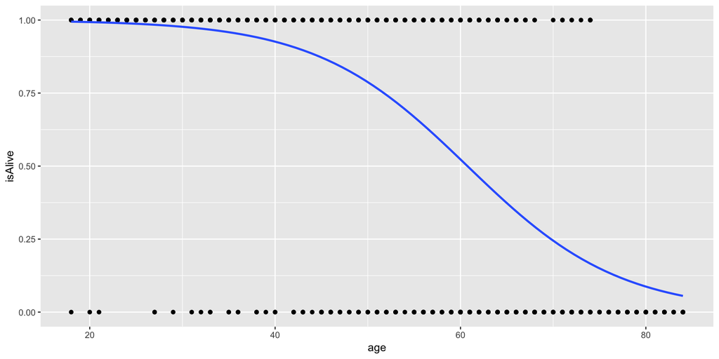

```r
ggplot(Whickham, aes(y=isAlive, x=age)) +  geom_point() +
  geom_smooth(method = "glm",  method.args = list(family = "binomial"), se = FALSE)
```

2. How can we interpret the coefficients of this model in the context of the problem?

```r
logm2 <- glm(isAlive ~ age + smoker, data=Whickham, family=binomial)
summary(logm)
```

[output not shown]

3. How does the `smoker` term affect the model?

##### Binning

Another way to make sense of a binary response variable is to **bin** the explanatory variable and then compute the average proportion of the response within each bin.

```r
Whickham <- Whickham %>%
  mutate(ageGroup = cut(age, breaks=10))
Whickham %>%
  group_by(ageGroup) %>%
  skim(isAlive)
```

```
## Skim summary statistics
##  n obs: 1314
##  n variables: 5
##  group variables: ageGroup
##
## ── Variable type:numeric ───────────────────────────────────────────────────────────────────────────────────────────────────
##     ageGroup variable missing complete   n mean   sd p0 p25 p50 p75 p100
##  (17.9,24.6]  isAlive       0      127 127 0.98 0.15  0   1   1   1    1
##  (24.6,31.2]  isAlive       0      191 191 0.98 0.14  0   1   1   1    1
##  (31.2,37.8]  isAlive       0      162 162 0.96 0.2   0   1   1   1    1
##  (37.8,44.4]  isAlive       0      144 144 0.91 0.29  0   1   1   1    1
##    (44.4,51]  isAlive       0      151 151 0.8  0.4   0   1   1   1    1
##    (51,57.6]  isAlive       0      128 128 0.71 0.46  0   0   1   1    1
##  (57.6,64.2]  isAlive       0      168 168 0.61 0.49  0   0   1   1    1
##  (64.2,70.8]  isAlive       0       92  92 0.23 0.42  0   0   0   0    1
##  (70.8,77.4]  isAlive       0       94  94 0.14 0.35  0   0   0   0    1
##  (77.4,84.1]  isAlive       0       57  57 0    0     0   0   0   0    0
##      hist
##  ▁▁▁▁▁▁▁▇
##  ▁▁▁▁▁▁▁▇
##  ▁▁▁▁▁▁▁▇
##  ▁▁▁▁▁▁▁▇
##  ▂▁▁▁▁▁▁▇
##  ▃▁▁▁▁▁▁▇
##  ▅▁▁▁▁▁▁▇
##  ▇▁▁▁▁▁▁▂
##  ▇▁▁▁▁▁▁▁
##  ▁▁▁▇▁▁▁▁
```

Although this is not the preferred method for performing logistic regression, it can be illustrative to see how the logistic curve fits through this series of points.

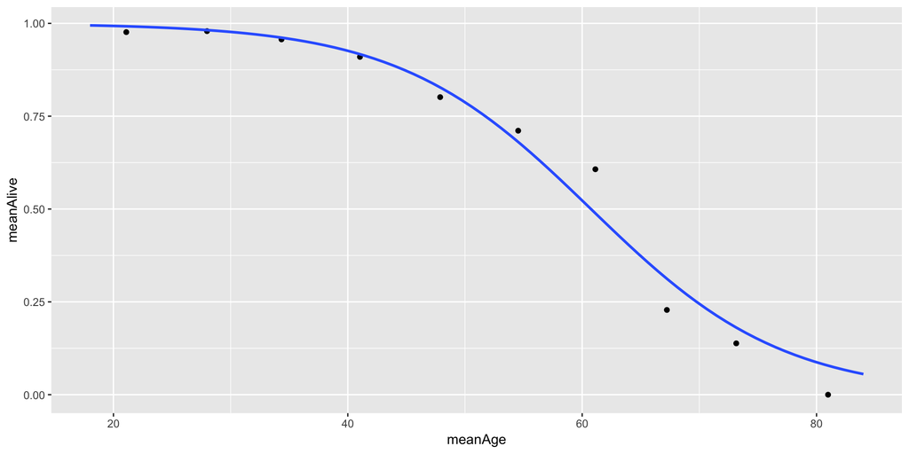

```r
binned <- Whickham %>%
  group_by(ageGroup) %>%
  dplyr::summarize(meanAlive = mean(isAlive), meanAge = mean(age))

ggplot() + geom_point(data=binned, aes(x=meanAge, y=meanAlive)) + geom_smooth(data=Whickham, aes(x=age, y=isAlive), method='glm', method.args = list(family = "binomial"), se = FALSE)
```

##### The Link Values

Consider now the difference between the fitted values and the link values. Although the fitted values do not follow a linear pattern with respect to the explanatory variable, the link values do. To see this, let’s plot them explicitly against the logit of the binned values.

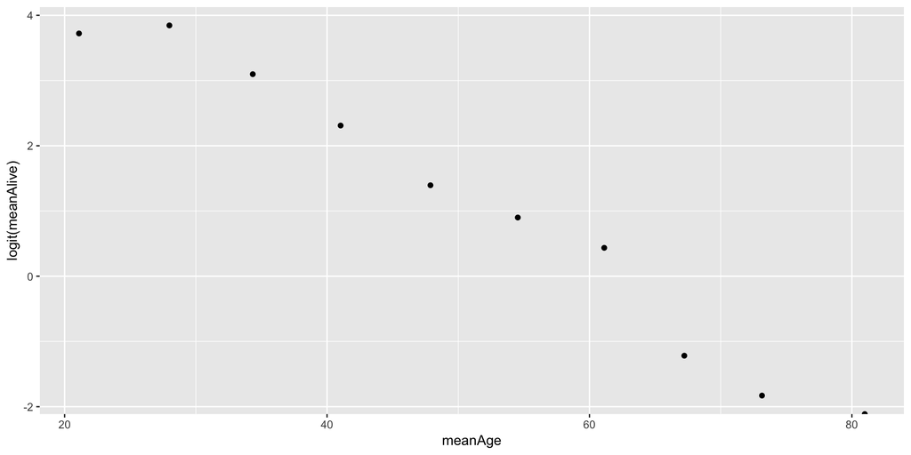

```r
ggplot(binned, aes(x=meanAge, y = logit(meanAlive))) + geom_point()
```

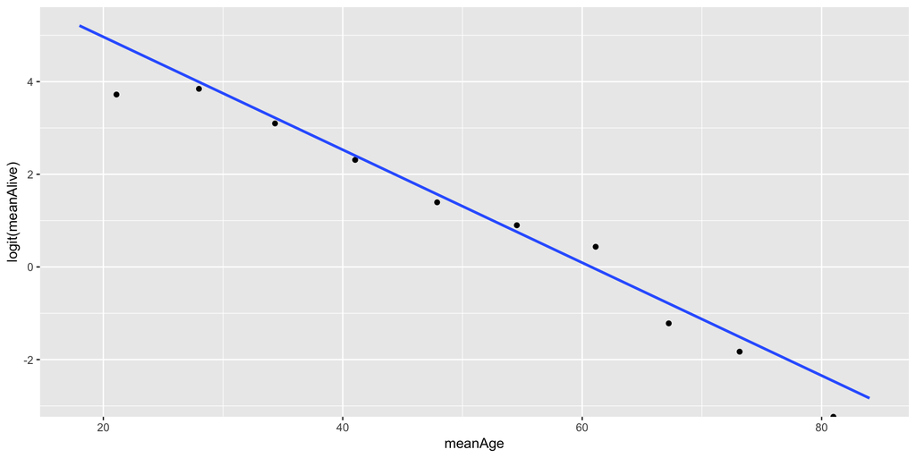

```r
Whickham <- Whickham %>%
  mutate(logmlink = predict(logm, type="link"))

ggplot() + geom_point(data=binned, aes(x=meanAge, y = logit(meanAlive))) + geom_smooth(data=Whickham, aes(x=age, y=logmlink), method="lm", se=FALSE)
```

Note how it is considerably easier for us to assess the quality of the fit visually using the link values, as opposed to the binned probabilities.

5. Why can’t we take the logit of the actual responses?

#### Odds Ratios and Interpretation of Coefficients

The interpretation of the coefficients in a linear regression model are clear based on an understanding of the geometry of the regression model. We use the terms *intercept* and *slope* because a simple linear regression model is a line. In a simple logistic model, the line is transformed by the logit function. How do the coefficients affect the shape of the curve in a logistic model?

See this shiny app https://ameliamn.shinyapps.io/log_app/ to experiment with changes to the intercept and slope coefficients in a simple logistic model.

8. How do changes in the intercept term affect the shape of the logistic curve?
9. How do changes in the slope term affect the shape of the logistic curve?

We saw earlier that the link values are linear with respect to the explanatory variable. The link values are the $\log$ of the **odds**. Note that if an event occurs with proability $\pi$, then
$$odds = \frac{\pi}{1-\pi}, \qquad \pi = \frac{odds}{1+odds}.$$
Note that while $\pi \in [0,1]$, $odds \in (0,\infty)$. Thus, we can interpret $\hat{\beta_1}$ as the typical change in $\log{(odds)}$ for each one unit increase in the explanatory variable. More naturally, the odds of success are multiplied by $e^{\hat{\beta_1}}$ for each one unit increase in the explanatory variable, since this is the **odds ratio**.
$$\begin{aligned}
odds_X &= \frac{\hat{\pi}_X}{1 - \hat{\pi}_X} = e^{\hat{\beta}_0 + \hat{\beta}_1 X} \\
odds_{X+1} &= \frac{\hat{\pi}_{X+1}}{1 - \hat{\pi}_{X+1}} = e^{\hat{\beta}_0 + \hat{\beta}_1 (X + 1)} \\
\frac{odds_{X+1}}{odds_X} &= \frac{e^{\hat{\beta}_0 + \hat{\beta}_1 (X + 1)}}{e^{\hat{\beta}_0 + \hat{\beta}_1 X}} = e^{\hat{\beta}_1}
\end{aligned}$$
Furthermore, since the *logits* are linear with respect to the explanatory variable, these changes are constant.

Finding confidence intervals for the odds ratio is easy. We could look at the point estimate and standard error from the `summary()` and use the `qnorm()` function to find a critical z value, or we could just use the convenience function `confint()`.

```r
exp(confint(logm))
```

```
##                   2.5 %       97.5 %
## (Intercept) 766.9449149 3736.9457926
## age           0.8728666    0.8969707
```